# GEOG 288CJ Homework 02

## Explain each term in 3.5.3f and what assumptions you need make to get to equation (1)

Term 1: Storage term. Change in mean potential temperature over change in time.

Term 2: Advective term. The redistribution of heat resulting from the mean winds.

Term 3: Sources and Sinks. The first is the diabatic heating term, which is representative of latent heat release. The second is the loss of heat through dissipation.

Term 4: Turbulent term. The eddy-driven redistibution of heat.

The assumptions made to get to Equation (1) and complete a simple growth rate model are:

1) The magnitude of the potential temperature jump (delta theta) remains constant as the boundary layer grows.

2) The rate of entrainment of warmer air from aloft is a fixed and known fraction of the surface heat flux. By this we can use the empirically-derived relationship that the heat flux at the top of the boundary layer can be constrained to approximately 20% of the surface flux and this gives us alpha.

```python
import numpy as np
import matplotlib.pyplot as plt
```

## 2)_ Use the simple for the growth rate of a convective BL discussed in class to obtain expressions for BL height h(t) and mixed layer potential temperature  (t), given that the surface heat flux is H_0= H_max sin〖(πt/12)〗 for 0 < t < 12, where t is time in hours. Your expression for  (t) should not contain h.

\begin{align} \frac{dh}{dt} = \frac{-(1 + 0.2) H_{o}}{-\gamma_{\theta} \rho C_{p} h} \end{align}

\begin{align} \int_0^{12} h\frac{dh}{dt}dt\ = \int_0^{12} \frac{-1.2H_o}{-\gamma_\theta\rho C_p}dt \end{align}

\begin{align} \int_0^{12} h\frac{dh}{dt}dt\ = \int_0^{12} \frac{-14.4H_{max}\cos(\frac{\pi t}{12})}{-\gamma_\theta \rho C_p \pi} \end{align}

\begin{align} \frac{h(t)^2 - h(t-1)^2}{2} = \frac{14.4 H_{max}}{-\gamma_\theta \rho C_{p} \pi} [\cos \frac{\pi t}{12} - \cos \frac{\pi (t-1)}{12}] \end{align}

\begin{align} h(t)^2 = \frac{28.8 H_{max}}{-\gamma_\theta \rho C_{p} \pi} [\cos \frac{\pi t}{12} - \cos \frac{\pi (t-1)}{12}] + h(t-1)^2 \end{align}

\begin{align} h(t) = \sqrt{\frac{28.8 H_{max}}{-\gamma_\theta \rho C_{p} \pi} [\cos \frac{\pi t}{12} - \cos \frac{\pi (t-1)}{12}] + h(t-1)^2} \end{align}

\begin{align} \frac{dh}{dt} = \frac{dh}{d\theta} \frac{d\theta}{dt} \end{align}

\begin{align} \frac{dh}{dt} = \frac{1}{-\gamma_\theta} \frac{d\theta}{dt} \end{align}

\begin{align} \int_0^{12} \frac{d\theta}{dt} = \int_0^{12} -\gamma_\theta \frac{dh}{dt} \end{align}

\begin{align} \int_0^{12} \frac{d\theta}{dt} = -\gamma_\theta \int_0^{12} \frac{dh}{dt} \end{align}

\begin{align} \theta(t) = -\gamma_\theta h(t) + C \end{align}

\begin{align} \theta(t) = -\gamma_\theta h(t) + \theta (0) + \gamma_\theta h(0) \end{align}

## 3) Plot h(t) and  (t) for 0 < t < 12, given that h(0) = 100 m and  (0) = 20C, for:

## a) A mildly stable atmosphere  = -2 C km-1

## b) A more stable atmosphere  = -5 C km-1

## Consider  = 0.2  = 1.2 kg m-3 Cp = 1004 J kg-1 K-1

```python
rho = 1.2
Cp = 1004
Hmax = 150 * 3600
gamma = [2/1000,5/1000]
def calc_conv_BL_a(gamma):
    h = np.zeros(13)
    h[0] = 100
    theta = np.zeros(13)
    theta[0] = 20
    for t in range(1,13):
        h[t] = np.sqrt(((2*1.2*12)*Hmax/(-gamma*rho*Cp*np.pi))*(np.cos(np.pi*t/12) - np.cos(np.pi*(t-1)/12))+h[t-1]*h[t-1])
        theta[t] = gamma*h[t] + theta[0] + gamma*h[0]
    return h,theta

h,theta = calc_conv_BL_a(gamma[0])
h_s,theta_s = calc_conv_BL_a(gamma[1])
```

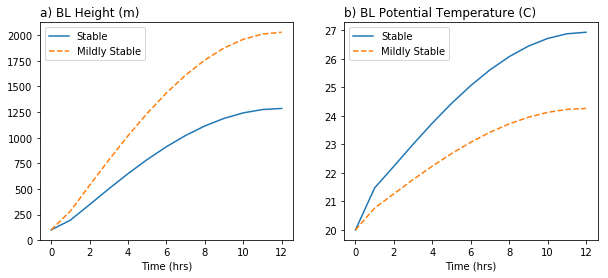

```python
fig, ax = plt.subplots(1,2, figsize=(10,4))

ax[0].plot(time,h_s)
ax[0].plot(time,h,linestyle='--')
ax[0].legend(['Stable','Mildly Stable'])
ax[0].set_title('a) BL Height (m)', loc='left')
ax[0].set_xlabel('Time (hrs)')

ax[1].plot(time,theta_s)
ax[1].plot(time,theta,linestyle='--')
ax[1].legend(['Stable','Mildly Stable'])
ax[1].set_title('b) BL Potential Temperature (C)', loc='left')
ax[1].set_xlabel('Time (hrs)')
plt.show()
```

The less stable boundary layer deepens more and quicker than the relatively stable boundary layer. In contrast to the boundary layer heights, the less stable boundary layer warms relatively slowly because a deeper boundary layer dissipates more heat, making it less efficient to heat the boundary layer.

## 4) How sensitive is the final BL height to the initial height h(0)? You may determine this sensitivity either analytically or computationally.

```python
def calc_conv_BL_f(ho,gamma=2):
    h = np.zeros(13)
    h[0] = ho
    theta = np.zeros(13)
    theta[0] = 20
    for t in range(1,13):
        h[t] = np.sqrt(((2*1.2*12)*Hmax/(-gamma*rho*Cp*np.pi))*(np.cos(np.pi*t/12) - np.cos(np.pi*(t-1)/12))+h[t-1]*h[t-1])
        theta[t] = gamma*h[t] + theta[0] + gamma*h[0]
    return h[-1],theta[-1]

h_ref,theta_ref = calc_conv_BL_f(100,gamma=gamma[0])
print('h_ref: '+str(h_ref)+' m')
print('theta_ref: ',str(theta_ref)+' C')

heights = np.arange(0,1000,step=1)
h = np.zeros(len(heights))
theta = np.zeros(len(heights))
for idx,ho in enumerate(heights):
    h[idx],theta[idx] = calc_conv_BL_f(ho,gamma=gamma[0])
```

```
h_ref: 2029.4976428202806 m
theta_ref:  24.258995285640562 C
```

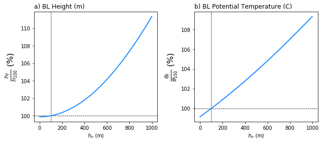

```python
fig, ax = plt.subplots(1,2, figsize=(10,4))

ax[0].axhline(100,c='black',linestyle='--',linewidth=0.75)
ax[0].axvline(100,c='black',linestyle='--',linewidth=0.75)
ax[0].plot(heights,h/h_ref*100,linewidth=2,color='dodgerblue')
#ax[0].legend(['Stable','Mildly Stable'])
ax[0].set_title('a) BL Height (m)', loc='left')
ax[0].set_xlabel(r'$h_o$ (m)')
ax[0].set_ylabel(r'$\frac{h_{f}}{h_{100}}$ (%)',fontsize=16)

ax[1].axhline(100,c='black',linestyle='--',linewidth=0.75)
ax[1].axvline(100,c='black',linestyle='--',linewidth=0.75)
ax[1].plot(heights,theta/theta_ref*100,linewidth=2,color='dodgerblue')
#ax[1].legend(['Stable','Mildly Stable'])
ax[1].set_title('b) BL Potential Temperature (C)', loc='left')
ax[1].set_xlabel(r'$h_o$ (m)')
ax[1].set_ylabel(r'$\frac{\theta_{f}}{\theta_{100}}$ (%)',fontsize=16)

#fig.suptitle('Percent change in final boundary layer value with change in initial height')
fig.subplots_adjust(wspace=0.3)
plt.show()
```